# *InVivo* Atlas Segmentation Examples

## **Example 3:** Application of segment labels to Cohen's D map of Mn(II)-enhancement.

We performed a paired t-test between post- and pre-Mn(II) images (n = 11), applied the optimal smoothing kernel, t-value threshold and cluster extent (see paper for details: kernel = 150 $\mu m$; T<sub>(10), p<0.05</sub> $\ge$ 1.81; cluster extent $\ge$ 8 voxels), and converted the T-map to Cohen's D. This masked Cohen's D effect size map representing effect sizes of suprathreshold (statistically signficant) voxels was then 'segmented' using InVivoSegment. Below we present those results in relation to noise.

```python
# Run GUI for statistical_tmap
# !python InVivoSegment.py --mode gui

# Note that we recommend running this in a separate terminal window, not as part of the Python kernel in a notebook as shown here. Example
```

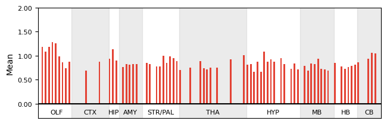

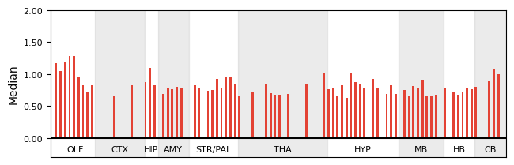

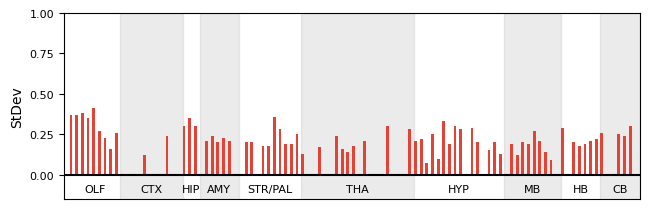

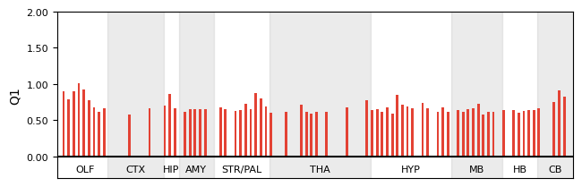

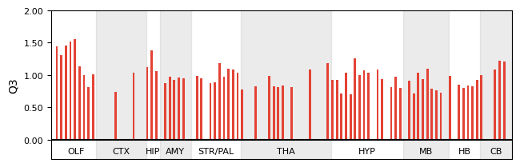

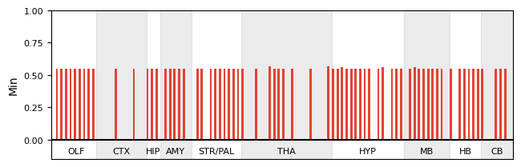

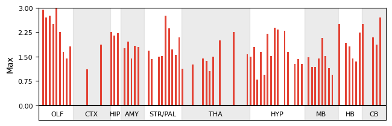

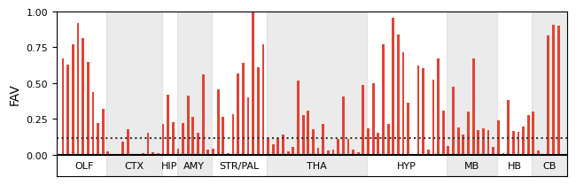

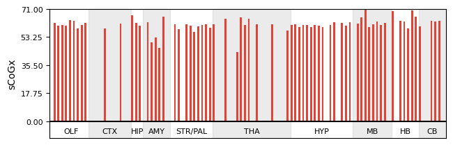

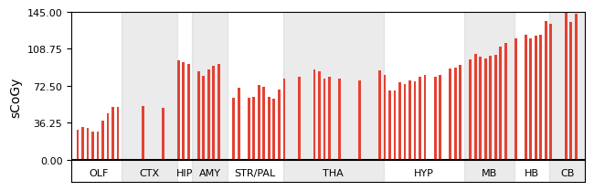

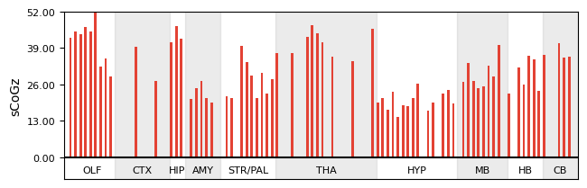

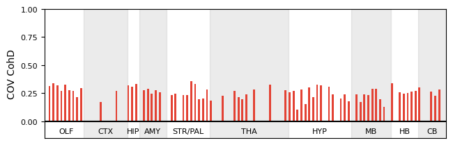

[5 more figures not shown]

```python
# Load SPM segmentation CSV
spm_df = pd.read_csv("./examples/statistical_tmap/OutputData/CSVs/SPMResults.csv", na_values=["", " ", "NA", "-"])

# Tranform a few variables
## Center of Gravity of Signal from Segmental CoG
spm_df['Euc Dist']  = np.sqrt((spm_df['sCoGx']-spm_df['CoGx'])**2 +
                              (spm_df['sCoGx']-spm_df['CoGx'])**2 +
                              (spm_df['sCoGz']-spm_df['CoGz'])**2) * 0.1
spm_df['Euc Distyz']  = np.sqrt((spm_df['sCoGx']-spm_df['CoGx'])**2 +
                                (spm_df['sCoGz']-spm_df['CoGz'])**2) * 0.1
spm_df['Euc Distx'] = (spm_df['sCoGx']-spm_df['CoGx']) * 0.1
spm_df['Euc Disty'] = (spm_df['sCoGy']-spm_df['CoGy']) * 0.1
spm_df['Euc Distz'] = (spm_df['sCoGz']-spm_df['CoGz']) * 0.1
# converted to mm
for index, row in spm_df.iterrows():
    if row["sCoGx"] == 0 and row["sCoGy"] == 0 and row["sCoGz"] == 0:
        spm_df.at[index,"Euc Dist"] = 0


spm_df['COV CohD']   = spm_df['StDev'] / spm_df['Mean']

# Plot SPM Segmental Statistics
for val in meanstd_val_df["Measure"]:
    if val in ["Mean CohD", "ActVol"]:
        continue
    # plot_name = os.path.join("./examples/statistical_tmap/OutputData/ColumnGraphs",("SPM_" + val + "_T181-C8_Mean.png"))
    plot_name = os.path.join("./examples/statistical_tmap/OutputData/ColumnGraphs",("SPM_" + val + "_T181-C8_Beta99th.png"))
    spm_df_tmp = spm_df.copy()
    if val == "FAV":
        plt(
            seg_df = spm_df_tmp,
            seg_rm = seg_to_remove,
            order = "Grouping",
            y = val,
            fill = "Condition",
            col_vals = ("#E34234", "#0000FF",
                        "#FFFF00", "#87CEEB"),
            save = False,
            fname = plot_name,
            fig_dims = dim_scale((3.3, 1.1), 2),
            font_scale = 2
            )
        fig = mplt.gcf()
        ax = mplt.gca()
        ax.axhline(y = threshold, color='0.2', linestyle='dotted', label=None)
        fig.savefig(plot_name, format='tiff', dpi=300, bbox_inches='tight')
    else:
        spm_df_tmp.loc[spm_df_tmp['FAV'] <= threshold, val] = 0
        plt(
            seg_df = spm_df_tmp,
            seg_rm = seg_to_remove,
            order = "Grouping",
            y = val,
            fill = "Condition",
            col_vals = ("#E34234", "#0000FF",
                        "#FFFF00", "#87CEEB"),
            save = False,
            fname = plot_name,
            fig_dims = dim_scale((3.3, 1.1), 2),
            font_scale = 2
            )
        fig = mplt.gcf()
        ax = mplt.gca()
        # mmag = meanstd_val_df.loc[meanstd_val_df["Measure"] == val, "Mean"].values[0]
        # ax.axhline(y = mmag, color='0.2', linestyle='dotted', label=None)
        # mmagu = meanstd_val_df.loc[meanstd_val_df["Measure"] == val, "3SD_upper"].values[0]
        # # ax.axhline(y = mmagu, color='0.4', linestyle='dotted', label=None)
        fig.savefig(plot_name, format='tiff', dpi=300, bbox_inches='tight')

spm_df_tmp = spm_df.copy()
spm_df_tmp["ActVol"] = np.log10(spm_df_tmp["ActVol"]+1)
# plot_name = os.path.join("./examples/statistical_tmap/OutputData/ColumnGraphs",("SPM_ActVollog10_T181-C8.png"))
plot_name = os.path.join("./examples/statistical_tmap/OutputData/ColumnGraphs",("SPM_ActVollog10_T181-C8_Beta99th.png"))
spm_df_tmp.loc[spm_df_tmp['FAV'] <= threshold, "ActVol"] = 0
ax = plt(
    seg_df = spm_df_tmp,
    seg_rm = seg_to_remove,
    order = "Grouping",
    y = "ActVol",
    fill = "Condition",
    col_vals = ("#E34234", "#0000FF",
                "#FFFF00", "#87CEEB"),
    save = False,
    fname = plot_name,
    fig_dims = dim_scale((3.3, 1.1), 2),
    font_scale = 2
    )
fig = mplt.gcf()
ax = mplt.gca()
# mmag = meanstd_val_df.loc[meanstd_val_df["Measure"] == "ActVol", "Mean"].values[0]
# ax.axhline(y = np.log10(mmag), color='0.2', linestyle='dotted', label=None)
# mmagu = meanstd_val_df.loc[meanstd_val_df["Measure"] == "ActVol", "3SD_upper"].values[0]
# ax.axhline(y = np.log10(mmagu), color='0.4', linestyle='dotted', label=None)
fig.savefig(plot_name, format='tiff', dpi=300, bbox_inches='tight')
```

```python
# determine how many segments survive at each threshold level

seg_ids = (spm_df["FAV"] > threshold) & (~spm_df["SegAbbr"].isin(seg_to_remove))
tot_segs = spm_df["FAV"][seg_ids].count()
print(f"Number of segments with FAV > {threshold:.4f}: {tot_segs}")

spm_df_filt = spm_df.loc[seg_ids,]
print(spm_df_filt["SegAbbr"][spm_df_filt["Mean"] == spm_df_filt["Mean"].max()])
print(spm_df_filt["SegAbbr"][spm_df_filt["COV CohD"] > 0.3].count())
print(spm_df_filt["SegAbbr"][spm_df_filt["Euc Dist"] == spm_df_filt["Euc Dist"].max()])
```

```
Number of segments with FAV > 0.1157: 69
57    MOBmi
Name: SegAbbr, dtype: object
16
70    BLA
Name: SegAbbr, dtype: object
```

```
['CB' 'HB' 'HYP' 'HIP' 'MB' 'STR/PAL' 'OLF' 'AMY' 'THA' 'CTX']
```

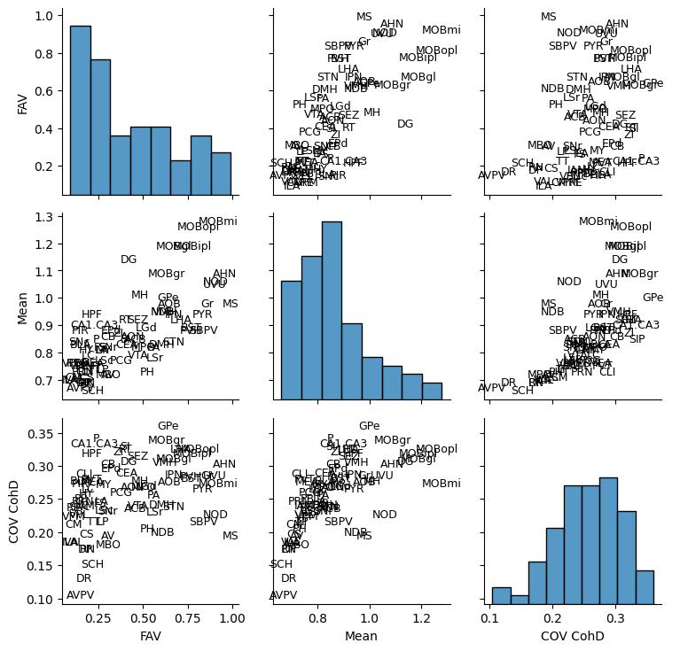

```python
# Correlations between Segmentation Statistics
import seaborn as sns

spm_df_filt = spm_df.loc[((spm_df["FAV"]>FAV_sdu) &
                          (~spm_df["Domain"].isin(["V","WB","WM"]))),
                          ['Domain','SegAbbr','FAV', 'Mean', 'COV CohD']].reset_index(drop=True)

print(spm_df_filt["Domain"].unique())
# Create a PairGrid object and map different plots to different sections
g = sns.PairGrid(spm_df_filt[['FAV', 'Mean', 'COV CohD']])
g.map_diag(sns.histplot)
g.map_offdiag(sns.scatterplot, alpha=0)
g.add_legend()

# Custom function to draw text instead of points
def label_points(x, y, labels, **kwargs):
    ax = mplt.gca()
    for val_x, val_y, label in zip(x, y, labels):
        if val_x != val_y:
            ax.text(val_x, val_y, label, fontsize=9, ha='center', va='center')

# Map the function to the grid
g.map(label_points, labels = spm_df_filt['SegAbbr'])
```

## **Example 4:** Intensity Maps of Post- and Pre-Mn(II) Brian Images

For this example we have the individual images (aligned but not smoothed) that were used as input for the SPM12 paired t-test in Example 3 above. In this case, images from multiple mice at two conditions have been segmented. Thus, we will plot the column graphs as the group average for a particular segmental statistic with error bars representing the standard error the mean. This result is not presented in the paper, but demonstrates how one would set up InVivo segmentation and graphical analysis of images from more complex experimental designs.

```python
# Run GUI for longitudinal_cross-sectional
#!python InVivoSegment.py --mode gui
```

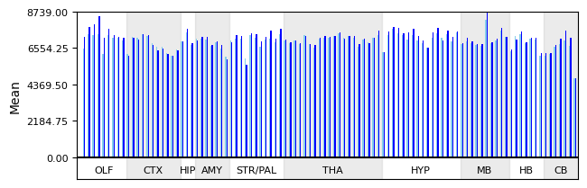

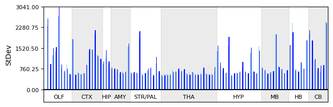

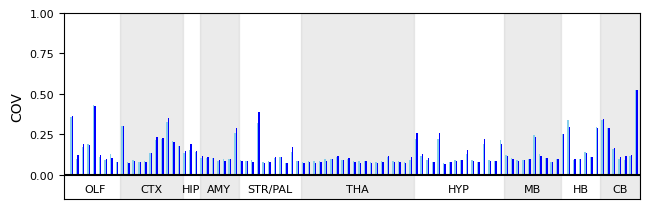

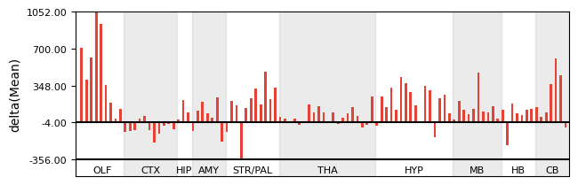

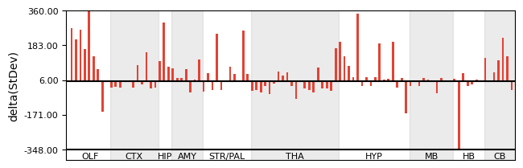

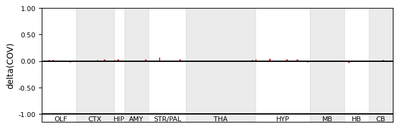

```python
# Load Intensity segmentation CSV
intensity_df = pd.read_csv("./examples/intensities/OutputData/CSVs/IntensityResults.csv", na_values=["", " ", "NA", "-"])

intensity_df["COV"] = intensity_df["StDev"] / intensity_df["Mean"]

# Plot SPM Segmental Statistics
for val in ("Mean", "StDev", "COV"):
    plot_name = os.path.join("./examples/intensities/OutputData/ColumnGraphs",("Intensity_" + val + "_thrNone.png"))
    #print(plot_name)
    ax = plt(
        seg_df = intensity_df,
        seg_rm = seg_to_remove,
        order = "Grouping",
        y = val,
        fill = "Condition",
        col_vals = ("#87CEEB", "#0000FF",
                    "#FFFF00", "#E34234", ),
        diff = None,
        save = True,
        fname = plot_name,
        fig_dims = dim_scale((3.3, 1.1), 2),
        font_scale = 2
        )

for val in ("Mean", "StDev", "COV"):
    # print(val)
    plot_name = os.path.join("./examples/intensities/OutputData/ColumnGraphs",("Intensity_" + val + "_thrNone.png"))
    #print(plot_name)
    ax = plt(
        seg_df = intensity_df,
        seg_rm = seg_to_remove,
        order = "Grouping",
        y = val,
        fill = "Condition",
        col_vals = ("#E34234", "#0000FF",
                    "#FFFF00", "#87CEEB"),
        diff = "diff",
        save = True,
        fname = plot_name,
        fig_dims = dim_scale((3.3, 1.1), 2),
        font_scale = 2
        )
```

Note that a new option has been added to the column graph plotting function "diff = diff" to indicate a difference calculation should take place between conditions. Options include "diff" for difference (con2 - con1) or "fc" for fold change (100*(con2/con1 - 1)). Note: this will only work if there are exactly 2 conditions in the 'Condition' column of the dataframe and if y is a numerical variable. Additionally, the resulting plot will only show the computed differences for the second condition (con2). If more than 2 conditions are used, a subset should be created frp, the dataframe with only the two desired conditions.